# Assignment for week 8

Joseph Walker

March 11, 2018

**Use the banking telemarketing dataset bank-additional-full.csv, (in bank-additional-full.zip posted on the Files/Assignment for Week 8) to build a model that determines whether a customer will subscribe to a bank term deposit (outcome variable “y”). Use logistic regression, decision trees (with hyperparameter optimization), and random forest models to generate your results. Evaluate and compare the performance of each type of model using appropriate tools and methods (e.g., confusion matrix, ROC/AUC).**

# Step 1: Import Data

```r
#load tidyverse for data wrangling
library(tidyverse)

#read in the data file
bank_data <- read.csv("bank-additional-full.csv", sep = ";", header = TRUE)
```

# Step 2: Tidy, Wrangle, Transform

Initially summarizing the data allows us to get a high level overview. We can see what type of variables we’re dealing with (nominal or categorical), whether or not there’s any missing data (NA’s or NULL’s), and how we may need to alter the data to work with it more efficiently.

```r
#examine the data
summary(bank_data)
```

```
##       age                 job            marital
##  Min.   :17.00   admin.     :10422   divorced: 4612
##  1st Qu.:32.00   blue-collar: 9254   married :24928
##  Median :38.00   technician : 6743   single  :11568
##  Mean   :40.02   services   : 3969   unknown :   80
##  3rd Qu.:47.00   management : 2924
##  Max.   :98.00   retired    : 1720
##                  (Other)    : 6156
##                education        default         housing
##  university.degree  :12168   no     :32588   no     :18622
##  high.school        : 9515   unknown: 8597   unknown:  990
##  basic.9y           : 6045   yes    :    3   yes    :21576
##  professional.course: 5243
##  basic.4y           : 4176
##  basic.6y           : 2292
##  (Other)            : 1749
##       loan            contact          month       day_of_week
##  no     :33950   cellular :26144   may    :13769   fri:7827
##  unknown:  990   telephone:15044   jul    : 7174   mon:8514
##  yes    : 6248                     aug    : 6178   thu:8623
##                                    jun    : 5318   tue:8090
##                                    nov    : 4101   wed:8134
##                                    apr    : 2632
##                                    (Other): 2016
##     duration         campaign          pdays          previous
##  Min.   :   0.0   Min.   : 1.000   Min.   :  0.0   Min.   :0.000
##  1st Qu.: 102.0   1st Qu.: 1.000   1st Qu.:999.0   1st Qu.:0.000
##  Median : 180.0   Median : 2.000   Median :999.0   Median :0.000
##  Mean   : 258.3   Mean   : 2.568   Mean   :962.5   Mean   :0.173
##  3rd Qu.: 319.0   3rd Qu.: 3.000   3rd Qu.:999.0   3rd Qu.:0.000
##  Max.   :4918.0   Max.   :56.000   Max.   :999.0   Max.   :7.000
##
##         poutcome      emp.var.rate      cons.price.idx  cons.conf.idx
##  failure    : 4252   Min.   :-3.40000   Min.   :92.20   Min.   :-50.8
##  nonexistent:35563   1st Qu.:-1.80000   1st Qu.:93.08   1st Qu.:-42.7
##  success    : 1373   Median : 1.10000   Median :93.75   Median :-41.8
##                      Mean   : 0.08189   Mean   :93.58   Mean   :-40.5
##                      3rd Qu.: 1.40000   3rd Qu.:93.99   3rd Qu.:-36.4
##                      Max.   : 1.40000   Max.   :94.77   Max.   :-26.9
##
##    euribor3m      nr.employed     y
##  Min.   :0.634   Min.   :4964   no :36548
##  1st Qu.:1.344   1st Qu.:5099   yes: 4640
##  Median :4.857   Median :5191
##  Mean   :3.621   Mean   :5167
##  3rd Qu.:4.961   3rd Qu.:5228
##  Max.   :5.045   Max.   :5228
##
```

Fortunately, this data set is rather clean but there are a few modifications to make. I personally find periods (.) annoying in column names so let’s change those.

```r
#for manipulating strings
library(stringr)

names(bank_data) <- str_replace_all(string = names(bank_data), pattern = '\\.', replacement = "_")
```

# Step 3: Modeling

Before we begin to build any models, we first need to split the data. We will split the data into a training set, a validation set, and a test set. The training set is used to build the model, the validation set is used for hyper parameter tuning, and the test set is used the evaluate the model performance.

*Be careful not to train and test a model with the same dataset. Since the purpose of building a predictive model is to make accurate predictions on events that have not yet occurred (future outcomes), we need a model that isn’t too specifc to the data set it was built upon. This is a term known as overfitting.*

Since our dataset is fairly large, we’ll use a 60/20/20 split to make the train/validation/test splits.

```r
set.seed(127)

# Randomly assign rows to ids (1/2/3 represents train/valid/test)
# This will generate a vector of ids of length equal to the number of rows
samp_assignment <- sample(1:3, size = nrow(bank_data), prob = c(.6, .2, .2), replace = TRUE)

# Create a train, validation and tests from the original data frame
bank_train <- bank_data[samp_assignment == 1, ]    # subset the student data frame to training indices only
bank_valid <- bank_data[samp_assignment == 2, ]  # subset the student data frame to validation indices only
bank_test <- bank_data[samp_assignment == 3, ]   # subset the student data frame to test indices only
```

And to make sure we split the data as intended:

```
## [1] "number of rows in full data set: 41188"
```

```
## [1] "Number of rows in training set:  24711"
```

```
## [1] "Number of rows in training set:  8114"
```

```
## [1] "Number of rows in test set:  8363"
```

### Logistic Regression

To start, let’s build a model using **logistic regression**.

First, we need a formula.

```r
fmla <- as.formula("y ~ .")
```

Our response variable in this case is `y` and the rest of the variables of the dataset are predictors, denoted by `.`

Now let’s build a logistic regression model using the `glm` function

```r
glm_model <- glm(formula = fmla, data = bank_train, family = binomial(link = "logit"))
```

To examine the model, we can use the `glance` function from the `broom` package.

```r
library(broom) # for tidying models

#examine the model terms
glance(glm_model)
```

```
##   null.deviance df.null    logLik      AIC      BIC deviance df.residual
## 1      17587.82   24710 -5129.989 10365.98 10796.07 10259.98       24658
```

Now, let’s proceed with making predictions on the test set.

```r
glm_preds <- predict(object = glm_model,
                 newdata = bank_test,
                 type = "response")
```

Using the `prediction` function, the predicted probabilities of the response variable are computed. In our case, we have predicted the probability of a customer subscribing to a bank term deposit. In order to convert probabilities to actual class predictions, a threshold must be set.

```r
#convert probabiities to classifications
glm_pred_class <- ifelse(glm_preds > 0.5, "yes", "no")

#Examine the error rate with a Confusion Matrix
library(caret)

glm_matrix <- caret::confusionMatrix(data = glm_pred_class, reference = bank_test$y, positive = "yes")

glm_matrix
```

```
## Confusion Matrix and Statistics
##
##           Reference
## Prediction   no  yes
##        no  7227  554
##        yes  208  374
##
##                Accuracy : 0.9089
##                  95% CI : (0.9025, 0.915)
##     No Information Rate : 0.889
##     P-Value [Acc > NIR] : 1.61e-09
##
##                   Kappa : 0.4482
##  Mcnemar's Test P-Value : < 2.2e-16
##
##             Sensitivity : 0.40302
##             Specificity : 0.97202
##          Pos Pred Value : 0.64261
##          Neg Pred Value : 0.92880
##              Prevalence : 0.11096
##          Detection Rate : 0.04472
##    Detection Prevalence : 0.06959
##       Balanced Accuracy : 0.68752
##
##        'Positive' Class : yes
##
```

It is useful to know that the *positive predicted class* can be specified with the `positive =` argument. Otherwise R defaults the positive value to the first level/factor. In the case of our data the default would be *no* so we should manually specify it.

The accuracy of the model is 0.909. That’s good!

Another useful statistic is the `no-information rate` which tells us how well our model would be at predicting the class probabilities in the case that no predictor variables are available. This is akin to purely guessing the class predictions. If the no-information rate is greater than the accuracy of the model, it’s time to start looking for some better predictors!

```r
#Is the Accuracy better than the NIR?
glm_matrix$overall["Accuracy"] > glm_matrix$overall["AccuracyNull"]
```

```
## Accuracy
##     TRUE
```

```r
#And the p-value that ACC > NIR
glm_matrix$overall["AccuracyPValue"]
```

```
## AccuracyPValue
##   1.609516e-09
```

This threshold can be modified to change the sensitivity and specificity of the model depending on what your purpose is. If we decrease the probability threshold, we allow more observations to be classified as **true positives**, which increases the **sensitivity** of the model. This comes at the cost of decreasing the **specificity** of the model since the **false positive** rate increases.

```r
#predictions with higher sensitivity
sensitive <- ifelse(glm_preds > .1, "yes", "no")

sensitive_matrix <- caret::confusionMatrix(data = sensitive, reference = bank_test$y, positive = "yes")

sensitive_matrix$table
```

```
##           Reference
## Prediction   no  yes
##        no  6250  106
##        yes 1185  822
```

In contrast, if we increase the probability threshold, we decrease the amount of observations classified as **true positives** but we increase the certainty of these observations being right. This also improves the model’s ability to correctly identify **true negatives**. In this case, the model’s sensitivity decreases, and the specificity increases.

```r
#predictions with higher specificity
specific <- ifelse(glm_preds > .9, "yes", "no")

specific_matrix <- caret::confusionMatrix(specific, bank_test$y, positive = "yes")

specific_matrix$table
```

```
##           Reference
## Prediction   no  yes
##        no  7411  853
##        yes   24   75
```

To finish up with this model, we’ll calculate the **area under the curve (AUC)**, of the receiver operating characteristic curve which is a metric we can use to compare the performance of different types of models. We’ll store the auc value for now and compare it to the other model’s aucs later.

*AUC can be calcualted with the `ModelMetrics` package.*

```r
library(ModelMetrics)

#AUC for the logistic regression model
glm_auc <- auc(actual = bank_test$y, predicted = glm_preds)
```

### Decision Tree

In this section, we’ll model the data using a decision tree. Tree based models are useful for making decisions or numeric predictions and have three main advantages: **they are easy to use, easy to interpret, and usually accurate.** We’ll also look at various hyper parameters which are like knobs we can tweak to tune the model.

To make a recursive partion decision tree, we’ll use the `rpart` package. One of the hyper parameters of a decision tree we can adjust is the **split criterion**. The purpose of a decision tree is to partition the data into groups as homogeneously as possible. The more hetergeneous a group is, the more impure it is. The measurement of this impurity is `gini` and is the default split criterion used in the `rpart` model function.

```r
library(rpart) #for modelling decision trees

#model data using rpart
tree_model <- rpart(formula = y ~ .,
                    data = bank_train,
                    method = "class",
                    parms = list(split = 'gini'))



tree_preds <- predict(object = tree_model,
                  newdata = bank_test,
                  type = 'class')
```

Now, let’s use the `information` splitting criterion which seeks to define the degree of disorganization in the dataset, also known as Entropy. The information split is based on the theory that less impure groups require less information to describe them. In other words, they do not have as much complexity and therefore are less disorganized.

```r
tree_model2 <- rpart(formula = y ~ .,
                    data = bank_train,
                    method = "class",
                    parms = list(split = 'information'))

tree_preds2 <- predict(object = tree_model2,
                  newdata = bank_test,
                  type = 'class')
```

We can visualize the decision trees using the `rpart.plot` package.

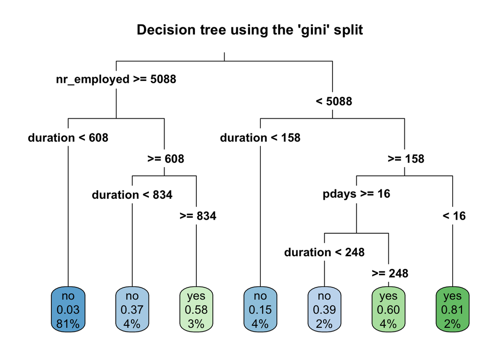

```r
library(rpart.plot) #for visualizing decision trees

#visualize the gini split model classification tree
rpart.plot(tree_model, type = 3, main= "Decision tree using the 'gini' split")
```

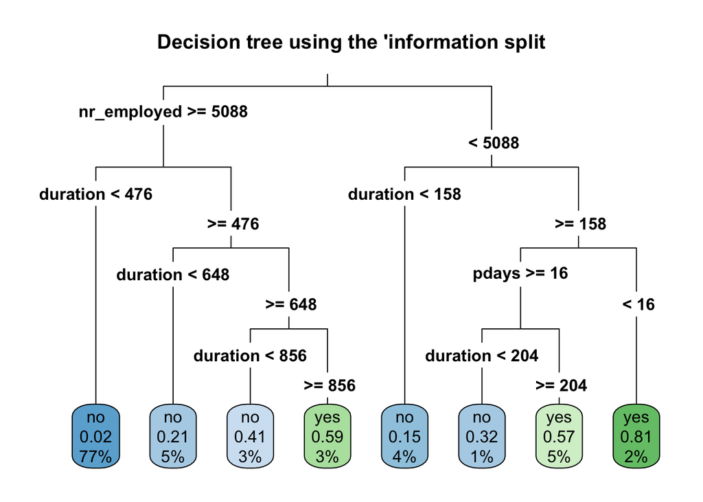

```r
#visualize the information split model classification tree
rpart.plot(tree_model2, type = 3, main= "Decision tree using the 'information split")
```

We can compare the models by calculating the **classification error** with the `ce` function from the `ModelMetrics` package. The classification error can be calculated as:
$$false\ positives\ +\ false\ negatives \over total\ observations$$

```r
library(ModelMetrics) # for calculating classification error

#compare the classification error of the models
paste("gini split model : ", round(ce(actual = bank_test$y, predicted = tree_preds) * 100, digits = 2), "%", sep = "")
```

```
## [1] "gini split model : 9.04%"
```

```r
paste("information split model: ", round(ce(actual = bank_test$y, predicted = tree_preds2)* 100, digits = 2),"%", sep = "")
```

```
## [1] "information split model: 9.27%"
```

Both models perform similarly and have a classification error rate of just over 9%.

The classification error is also: *1- accuracy* which can be calcualted as:
$$true\ positives\ +\ true\ negatives \over total\ observations$$

Rather than having to do the math each time, we can obtain the accuracy from the confusion matrix function.

Now, let’s examine the models in more detail by looking at the accuracy and confusion matrices for each.

*Be careful when calling a confusion matrix because both the caret and Model Metrics packages have a confusion matrix function. While they behave similarly, the names of the arguments differ slightly and may throw you off depending which function is being called.*

```r
#confusion marix with gini split model
gini_matrix <- caret::confusionMatrix(data = tree_preds, reference = bank_test$y, positive = "yes")

#confusion matrix with information split model
info_matrix <- caret::confusionMatrix(data = tree_preds2, reference = bank_test$y, positive = "yes")

gini_matrix$overall["Accuracy"]
```

```
##  Accuracy
## 0.9096018
```

```r
gini_matrix$table
```

```
##           Reference
## Prediction   no  yes
##        no  7153  474
##        yes  282  454
```

```r
info_matrix$overall["Accuracy"]
```

```
##  Accuracy
## 0.9073299
```

```r
info_matrix$table
```

```
##           Reference
## Prediction   no  yes
##        no  7111  451
##        yes  324  477
```

From a practical standpoint, the accuracy of the models is about the same. The model using the information split does a slightly better job at predicting customers who will subscribe to a bank term deposit. We can say that this model has a higher sensitivity since it has a higher true positive rate. However, this comes at the cost of having a higher false positive rate. This explains why this model has a slightly lower accuracy that the model using the gini split.

From a business standpoint, the right model depends on your tolerance for predicting incorrectly. If the cost to be wrong is too high, you’d want a model with a higher specificity; you’ll have less true positives but you’ll be more confident in the probability that they are right. On the other hand, if you can tolerate more error, the model that identifies more true positives (at the cost of more false positives) has a higher sensitivity and may be the right one for you.

### Other hyper parameters

The other primary tuning parameters used to adjust decision trees are **minsplit, maxdepth,** and **complexity probability (cp)**.

Rather than manually tweaking each parameter manually in a process of trial and error, we can use a hyper grid to iterate over combinations of hyper paramaters to find the optimized model in an efficient manner.

```r
minsplit <- c(1, 500, 1000, 1500)
maxdepth <- seq(from = 3, to = 12, by = 3)

hypergrid <- expand.grid(minsplit = minsplit, maxdepth = maxdepth)

tree_models <- list()

for(i in 1:nrow(hypergrid)){
  mycontrol <- rpart.control(minsplit = hypergrid$minsplit[i],
                             maxdepth = hypergrid$maxdepth[i])

  tree_models[[i]] <- rpart(formula = y ~ .,
                 data = bank_train,
                 method = "class",
                 control = mycontrol)
}
```

Now that we have 16 models, our goal is to find the model with the best performance. To do so, we’ll use the validation data set to make predictions on each of the models and use the classification error metric to compare them. The model with the lowest classification error is our winner.

```r
#create an empty vector to store the CE rates
class_errors <- c()

#loop over the models to make predictions and calculate the CE
for(i in 1:length(tree_models)){

  #retrieve the i'th model
  model <- tree_models[[i]]

  #make predictions on the i'th model
  predictions <- predict(object = model,
                         newdata = bank_valid,
                         type = "class")

  #save i'th model classification error to class_errors vector
  class_errors[i] <- ce(actual = bank_valid$y, predicted = predictions)
}

#identify best tree model that give the lowest classification error
best_tree <- tree_models[[which.min(class_errors)]]

#examine the best tree model parameters
best_tree$control
```

```
## $minsplit
## [1] 1
##
## $minbucket
## [1] 0
##
## $cp
## [1] 0.01
##
## $maxcompete
## [1] 4
##
## $maxsurrogate
## [1] 5
##
## $usesurrogate
## [1] 2
##
## $surrogatestyle
## [1] 0
##
## $maxdepth
## [1] 6
##
## $xval
## [1] 10
```

Finally, we’ll utilize the best_model to make predictions on the test dataset.

```r
#use best model to make predictions on test set
best_tree_preds <- predict(object = best_tree,
                           newdata = bank_test,
                           type = "class")

#calculate the classification error rate
best_ce <- ce(actual = bank_test$y, predicted = best_tree_preds)
```

After all that work, our optimized model returns a classification error rate of 9.04%. While this may not be much better than the earlier models, it’s important to examine the confusion matrix to see how it classifies true positives and true negatives. As we discussed earlier, the model may be more or less desireable depending on the classification error type rates that fit your needs.

```r
best_cm <- caret::confusionMatrix(data = best_tree_preds, reference = bank_test$y, positive = "yes")

best_cm$overall["Accuracy"]
```

```
##  Accuracy
## 0.9096018
```

```r
best_cm$table
```

```
##           Reference
## Prediction   no  yes
##        no  7153  474
##        yes  282  454
```

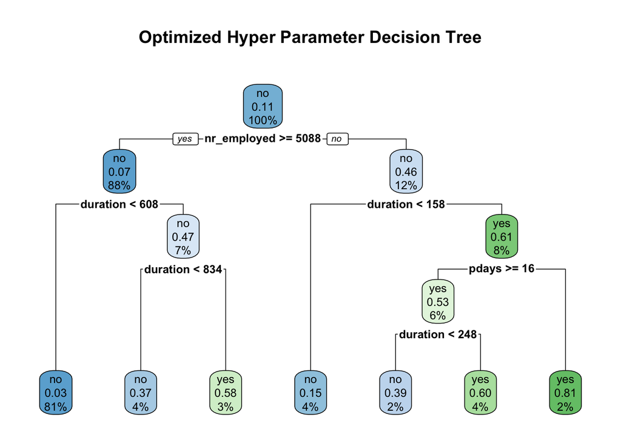

```r
rpart.plot(best_tree, main = "Optimized Hyper Parameter Decision Tree")
```

Now let’s calculate the AUC for the decision tree model.

```r
#auc for decision tree model
dt_auc <- auc(actual = bank_test$y, predicted = best_tree_preds)
```

### Random Forest Model

The last type of model we’ll explore is the **random forest**. Random forest modeling uses the ensemble method in which many classification trees are built and aggregated to find the best one. At each split of the tree, only a random subset of variables are used in order to reduce the correlation between sampled trees.

Each tree in a random forest model is created using a bootstrapped sample of the dataset used to train the model. In order to compare all the trees of the model, random forests compute the **out of bag error rate** for each tree by testing the data that was not included in the bootstrapped sample (this is know as out of bag data) and comparing it to the true classification values to calculate the classification error.

To make a random forest model, we’ll use the `randomForest` package but be aware that you can also use the `ranger` package.

As a reminder, each tree in a random forest is made using a random bootstrapped sample so we’ll use the `set.seed` function for reproducibility.

```r
#load the random Forest package
library(randomForest)

#set the seed for reproducibility
set.seed(3918)

rf_model <- randomForest(formula = y ~ ., data = bank_train)

#examine the random forest model
rf_model
```

```
##
## Call:
##  randomForest(formula = y ~ ., data = bank_train)
##                Type of random forest: classification
##                      Number of trees: 500
## No. of variables tried at each split: 4
##
##         OOB estimate of  error rate: 8.58%
## Confusion matrix:
##        no  yes class.error
## no  21041  840  0.03838947
## yes  1280 1550  0.45229682
```

Right out of the box, or rather, out of the bag I should say, the random forest model estimates an out of bag error rate of 8.579%. The confusion matrix indicates that the model is more specific than it is sensitive since the **true negative** rate is much greater than the **true positive** rate.

Like the models we trained in earlier sections, random forest also have hyper parameters we can tune:

- ntree: number of trees (default is set at 500)
- mtry: number of variables randomly sampled as candidates at each split
- sampsize: number of samples to train on
- nodesize: minimum size (number of samples) of the terminal nodes
- maxnodes: maximum number of terminal nodes

Before we dive in, let’s visualize the random forest model witha call to the `plot` function

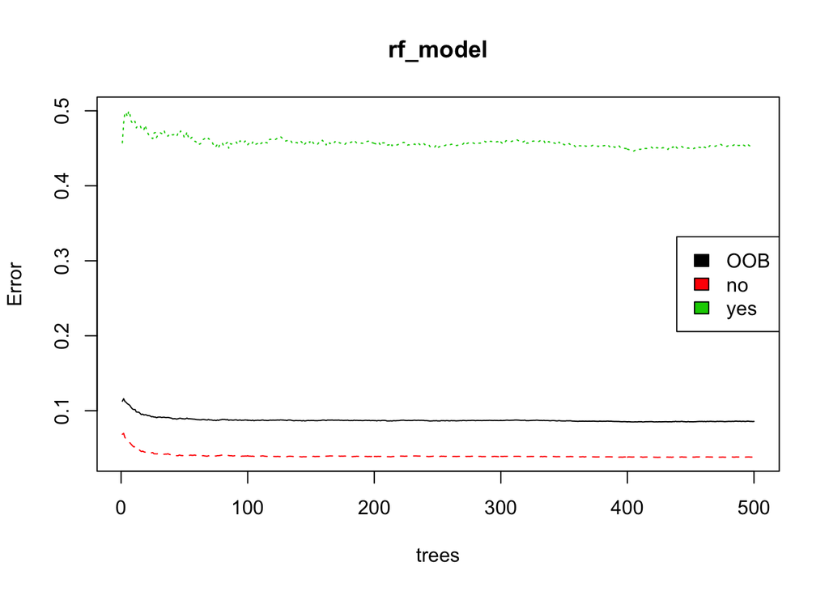

```r
#plot the random forest model
plot(rf_model)

# Add a legend
legend(x = "right",
       legend = colnames(rf_model$err.rate),
       fill = 1:ncol(rf_model$err.rate))
```

Generally, we can improve the model with a greater number of trees but this comes at the cost of the time it takes to generate the model. The default value is set to 500. As the plot shows, the model reaches a minimum error rate at less than 100 trees so it doesn’t really make sense for us to tweak the **ntree** parameter.

As for the **mtry** hyper parameter, the `randomForest` package has a specific function for optimizing the mtry value and that is `tuneRF()`. The function starts with the default mtry value and iterates stepwise by some specified value in the left and right direction to find the mtry value that leads to the lowest OOB error estimate.

```
## mtry = 4  OOB error = 8.58%
## Searching left ...
## mtry = 2     OOB error = 9.02%
## -0.05191128 0.05
## Searching right ...
## mtry = 8     OOB error = 8.66%
## -0.009910335 0.05
```

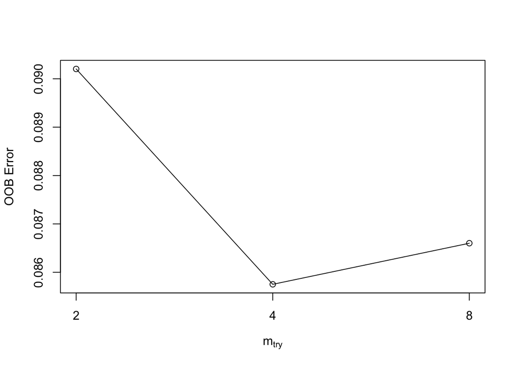

```r
#set the seed for reproducibility
set.seed(57)

#optimize the mtry hyper paramter with tuneRF
tuned_mtry_rf <- tuneRF(x = select(bank_train, -y),
                     y = bank_train$y,
                     ntreeTry = 500,
                     plot = T, #defaults to True
                     doBest = T #defaults to False
)
```

```r
tuned_mtry_rf
```

```
##
## Call:
##  randomForest(x = x, y = y, mtry = res[which.min(res[, 2]), 1])
##                Type of random forest: classification
##                      Number of trees: 500
## No. of variables tried at each split: 4
##
##         OOB estimate of  error rate: 8.53%
## Confusion matrix:
##        no  yes class.error
## no  21048  833  0.03806956
## yes  1275 1555  0.45053004
```

So it appears that an mtry of 4 gives us the lowest OOB error rate. Let’s continue looking at the other parameters.

The **sampsize** is a bit tricky. By default, the `randomForest` model algorithm uses a bootstrap sample approach where the n of the sample is equal the number of observations in the dataset. Furthermore, it uses sampling with replacement to generate the randomness of the sampling for each tree. In general, this default method is sufficient but we can specify the number of samples used. Of course, there are drawbacks. If we use a smaller sample size, we increase the variation in each tree, but we may sacrifice performance of the model. On the other hand, increasing the sample size will lead to less randomness and may lead to overfitting.

Depending on the size of your data or whether you have specific classification criteria you have in mind, it may or may not makes sense to tune the **nodesize** and **maxnodes**.

Again, we can set up a hyper grid to build a list of models trying all the different combinations of hyper paramters we specify.

```r
#utilize the optimized mtry value above and
# establish a list of possible values for nodesize
mtry <- 4
maxnodes <- seq(from = 5, to = 13, by = 2)
sampsize <- floor(nrow(bank_train) * c(.5, .8))

# Create a data frame containing all combinations
hyper_grid <- expand.grid(mtry = mtry, maxnodes = maxnodes, sampsize = sampsize)

# Create an empty list to store the models
rf_models <- list()

#set seed for reproducibility
set.seed(99)

# Write a loop over the rows of hyper_grid to train the grid of models
for (i in 1:nrow(hyper_grid)){

  # Train a Random Forest model
  rf_models[[i]] <- randomForest(formula = y ~ .,
                        data = bank_train,
                        mtry = mtry,
                        maxnodes = hyper_grid$maxnodes[i],
                        sampsize = hyper_grid$sampsize[i],
                        replace = T)
}
```

Now let’s identify the optimal hyper parameters by choosing the model with the lowest OOB error rate.

```r
#extract the minimum OOB error rates for each model
rf_oobs <- unlist(map(.x = rf_models, .f = function(x) x$err.rate[nrow(hyper_grid), 'OOB']))

#get the hyper parameters corresponding to the model with the lowest OOB error rate
hyper_grid[which.min(rf_oobs), ]
```

```
##   mtry maxnodes sampsize
## 9    4       11    19768
```

And now we can look at the model that utilizes these hyper parameters.

```r
#get the model that has the minimum oob
best_rf <- rf_models[[which.min(rf_oobs)]]

#examine the best random forest model
best_rf
```

```
##
## Call:
##  randomForest(formula = y ~ ., data = bank_train, mtry = mtry,      maxnodes = hyper_grid$maxnodes[i], sampsize = hyper_grid$sampsize[i],      replace = T)
##                Type of random forest: classification
##                      Number of trees: 500
## No. of variables tried at each split: 4
##
##         OOB estimate of  error rate: 9.97%
## Confusion matrix:
##        no yes class.error
## no  21682 199 0.009094648
## yes  2264 566 0.800000000
```

Finally, let’s calculate the AUC for the random forest model. Since we have not made predictions on the test set with the random forest model yet, let’s do that first.

```r
#make predictions on test dataset using the tuned_mtry_rf model.
rf_preds <- predict(object = tuned_mtry_rf,
                    newdata = bank_test)

#calculate auc for the rf predictions
rf_auc <- auc(actual = bank_test$y, predicted = rf_preds)
```

# Step 4: Comparing Models

Throughout this assignment, we’ve explored different types of models: logistic regression, decision trees, and random forests. Within these model types, we’ve explored different hyper parameters while seeking to improve the various models. Now it’s time to compare the models to each other. In order to do so, we need a metric that normalizes the model performance to a relative scale. We’ll use the area under the curve (AUC), which we’ve alread calculated for each model.

```r
sprintf("logistic regression model test AUC: %.3f", glm_auc)
```

```
## [1] "logistic regression model test AUC: 0.931"
```

```r
sprintf("recursive partitioning decision tree test AUC: %.3f", dt_auc)
```

```
## [1] "recursive partitioning decision tree test AUC: 0.726"
```

```r
sprintf("random forest model test AUC: %.3f", rf_auc)
```

```
## [1] "random forest model test AUC: 0.733"
```

And there you have it. The logistic regression model takes the cake. In the final feature, let’s visualize the model performance with the ROC curves.

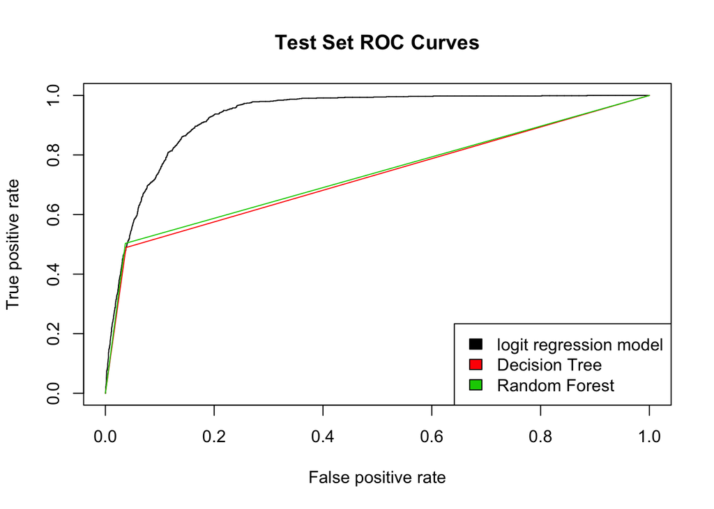

```r
#load the ROCR package
library(ROCR)

# List of predictions
preds_list <- list(glm_preds, best_tree_preds, rf_preds)

# List of actual values (same for all)
m <- length(preds_list)

actuals_list <- rep(list(bank_test$y), m)

# Plot the ROC curves
pred <- prediction(predictions = preds_list, labels = actuals_list)
rocs <- performance(prediction.obj = pred, measure = "tpr", x.measure = "fpr")
plot(rocs, col = as.list(1:m), main = "Test Set ROC Curves")
legend(x = "bottomright",
       legend = c("logit regression model", "Decision Tree", "Random Forest"),
       fill = 1:m)
```